# *Desarrollo notebook 4*

### *Selección de variables*

### **Importar librerías**

```python
import pandas as pd
import numpy as np
import matplotlib.pyplot as plt
import seaborn as sns
from sklearn.linear_model import Lasso
from sklearn.ensemble import RandomForestClassifier
from lightgbm import LGBMClassifier
from sklearn.linear_model import LogisticRegression
from sklearn.feature_selection import SelectFromModel
from imblearn.under_sampling import RandomUnderSampler
from sklearn.model_selection import cross_val_score

seed = 42
```

#### En el anterior paso es posible visualizar una variable denominada 'seed', la cual es sustancial emplearla a lo largo de procesos de programación, debido a que genera reproducibilidad, controla la aleatoriedad, te permite comparar modelos y prevenir errores experimentales.

### **Lectura de datos con variables seleccionadas**

```python
X_train = pd.read_csv('/Users/miguelflores/Desktop/DF/X_train.csv').set_index('SK_ID_CURR')
X_test = pd.read_csv('/Users/miguelflores/Desktop/DF/X_test.csv').set_index('SK_ID_CURR')

y_train = pd.read_csv('/Users/miguelflores/Desktop/DF/y_train.csv').set_index('SK_ID_CURR')
y_test = pd.read_csv('/Users/miguelflores/Desktop/DF/y_test.csv').set_index('SK_ID_CURR')
```

## **Selección de variables**

### *Lasso (Least Absolute Shrinkage and Selection Operator)*

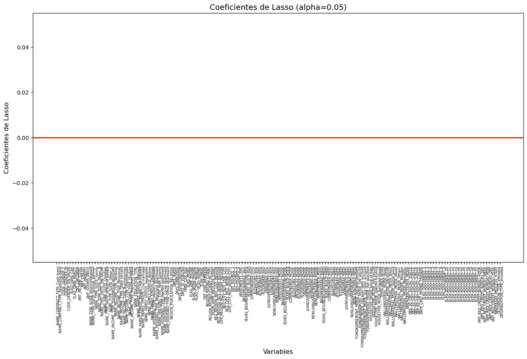

```
Variables seleccionadas para alpha=0.05:
Cantidad de variables seleccionadas: 0
```

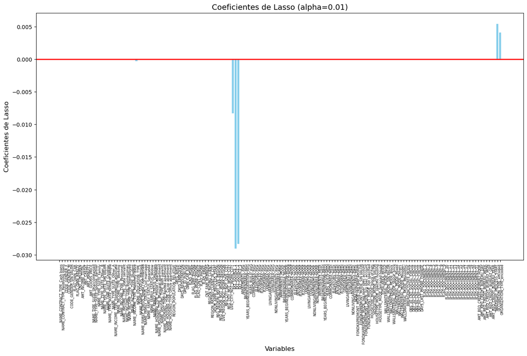

```
Variables seleccionadas para alpha=0.01:
OCCUPATION_TYPE_encoded                     0.00536
ORGANIZATION_TYPE_encoded                   0.00409
NAME_EDUCATION_TYPE                        -0.00032
EXT_SOURCE_1                               -0.00832
EXT_SOURCE_3                               -0.02834
EXT_SOURCE_2                               -0.02905
Cantidad de variables seleccionadas: 6
```

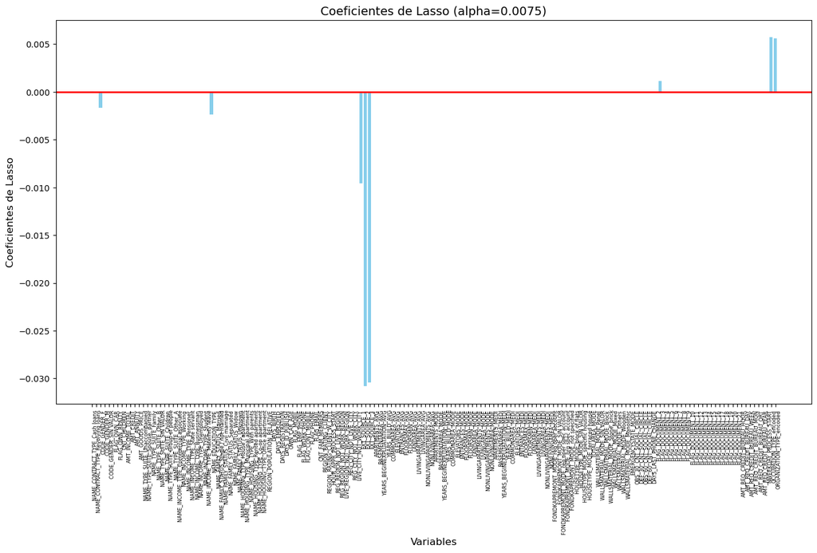

```
Variables seleccionadas para alpha=0.0075:
OCCUPATION_TYPE_encoded                     0.00569
ORGANIZATION_TYPE_encoded                   0.00559
FLAG_DOCUMENT_3                             0.00111
NAME_CONTRACT_TYPE_Cash loans               0.00003
CODE_GENDER_M                               0.00001
NAME_CONTRACT_TYPE_Revolving loans         -0.00000
CODE_GENDER_F                              -0.00165
NAME_EDUCATION_TYPE                        -0.00236
EXT_SOURCE_1                               -0.00955
EXT_SOURCE_3                               -0.03042
EXT_SOURCE_2                               -0.03082
Cantidad de variables seleccionadas: 11
```

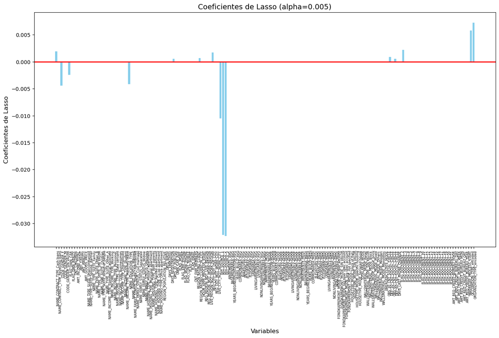

```
Variables seleccionadas para alpha=0.005:
ORGANIZATION_TYPE_encoded                   0.00721
OCCUPATION_TYPE_encoded                     0.00580
FLAG_DOCUMENT_3                             0.00220
NAME_CONTRACT_TYPE_Cash loans               0.00192
REG_CITY_NOT_LIVE_CITY                      0.00173
DEF_30_CNT_SOCIAL_CIRCLE                    0.00086
REGION_RATING_CLIENT_W_CITY                 0.00067
DEF_60_CNT_SOCIAL_CIRCLE                    0.00055
DAYS_ID_PUBLISH                             0.00053
CODE_GENDER_M                               0.00002
NAME_CONTRACT_TYPE_Revolving loans         -0.00000
NAME_FAMILY_STATUS_Married                 -0.00009
FLAG_OWN_CAR                               -0.00241
NAME_EDUCATION_TYPE                        -0.00412
CODE_GENDER_F                              -0.00441
EXT_SOURCE_1                               -0.01049
EXT_SOURCE_2                               -0.03217
EXT_SOURCE_3                               -0.03236
Cantidad de variables seleccionadas: 18
```

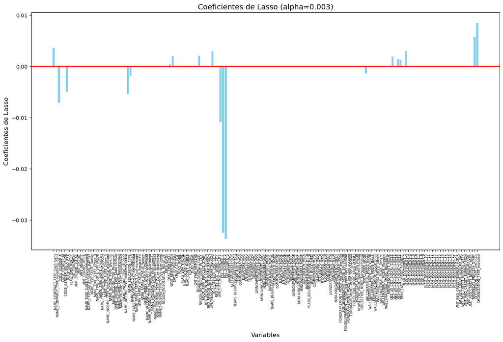

```
Variables seleccionadas para alpha=0.003:
ORGANIZATION_TYPE_encoded                   0.00844
OCCUPATION_TYPE_encoded                     0.00576
NAME_CONTRACT_TYPE_Cash loans               0.00362
FLAG_DOCUMENT_3                             0.00300
REG_CITY_NOT_LIVE_CITY                      0.00293
REGION_RATING_CLIENT_W_CITY                 0.00209
DAYS_ID_PUBLISH                             0.00196
DEF_30_CNT_SOCIAL_CIRCLE                    0.00194
DEF_60_CNT_SOCIAL_CIRCLE                    0.00144
DAYS_LAST_PHONE_CHANGE                      0.00136
DAYS_REGISTRATION                           0.00037
CODE_GENDER_M                               0.00003
NAME_INCOME_TYPE_Working                    0.00003
NAME_CONTRACT_TYPE_Revolving loans         -0.00000
WALLSMATERIAL_MODE_Panel                   -0.00138
NAME_FAMILY_STATUS_Married                 -0.00193
FLAG_OWN_CAR                               -0.00502
NAME_EDUCATION_TYPE                        -0.00546
CODE_GENDER_F                              -0.00711
EXT_SOURCE_1                               -0.01088
EXT_SOURCE_2                               -0.03250
EXT_SOURCE_3                               -0.03373
Cantidad de variables seleccionadas: 22
```

```python
a = [0.05, 0.01, 0.0075, 0.005, 0.003]

for valor in a:
    # Ajustar el modelo Lasso conforme al alpha
    lasso = Lasso(alpha=valor)
    lasso.fit(X_train, y_train)

    # Obtener las características seleccionadas (coeficientes diferentes a 0)
    variables_lasso = X_train.columns[(lasso.coef_ != 0)]

    # Obtener los coeficientes de las variables seleccionadas
    coeficientes = lasso.coef_[(lasso.coef_ != 0)]  # Los coeficientes correspondientes a las variables seleccionadas

    # Crear una lista de tuplas (variable, coeficiente)
    variables_coef = list(zip(variables_lasso, coeficientes))

    # Ordenar las variables por los coeficientes en orden descendente
    variables_coef_sorted = sorted(variables_coef, key=lambda x: x[1], reverse=True)

    # Redondear los coeficientes a 5 decimales
    variables_coef_sorted = [(var, round(coef, 5)) for var, coef in variables_coef_sorted]

    # Graficar coeficientes de Lasso
    plt.figure(figsize=(16, 10))
    plt.bar(X_train.columns, lasso.coef_, color='skyblue')

    # Línea de 0
    plt.axhline(y=0, color='red', linestyle='-', linewidth=2)

    # Configuración del gráfico
    plt.ylabel('Coeficientes de Lasso', fontsize=12)
    plt.xlabel('Variables', fontsize=12)
    plt.title(f'Coeficientes de Lasso (alpha={valor})', fontsize=14)

    # Ajustar la visualización de las etiquetas en el eje X
    plt.xticks(rotation=90, ha='right', rotation_mode='anchor', fontsize=6)

    # Aumentar el espaciado entre las etiquetas en el eje X
    plt.subplots_adjust(bottom=0.25)

    # Mostrar el gráfico
    plt.show()

    # Imprimir las variables seleccionadas con sus coeficientes, redondeados y ordenados
    print(f'Variables seleccionadas para alpha={valor}:')

    # Alinear las variables y coeficientes y evitar notación científica
    for var, coef in variables_coef_sorted:
        print(f'{var:<40} {coef:>10.5f}')

    # Imprimir la cantidad de variables seleccionadas
    print(f'Cantidad de variables seleccionadas: {len(variables_lasso)}')
```

```python
variables_lasso
```

```
Index(['NAME_CONTRACT_TYPE_Cash loans', 'NAME_CONTRACT_TYPE_Revolving loans',
       'CODE_GENDER_F', 'CODE_GENDER_M', 'FLAG_OWN_CAR',
       'NAME_INCOME_TYPE_Working', 'NAME_EDUCATION_TYPE',
       'NAME_FAMILY_STATUS_Married', 'DAYS_REGISTRATION', 'DAYS_ID_PUBLISH',
       'REGION_RATING_CLIENT_W_CITY', 'REG_CITY_NOT_LIVE_CITY', 'EXT_SOURCE_1',
       'EXT_SOURCE_2', 'EXT_SOURCE_3', 'WALLSMATERIAL_MODE_Panel',
       'DEF_30_CNT_SOCIAL_CIRCLE', 'DEF_60_CNT_SOCIAL_CIRCLE',
       'DAYS_LAST_PHONE_CHANGE', 'FLAG_DOCUMENT_3', 'OCCUPATION_TYPE_encoded',
       'ORGANIZATION_TYPE_encoded'],
      dtype='object')
```

#### La técnica de **Lasso** (Least Absolute Shrinkage and Selection Operator) es una técnica que aplica regularización L1, penalizando los coeficientes de las variables. En este caso se presenta una iteración en varios valores de alpha, los cuales van decreciendo para así hacer énfasis en que al presentar un menor valor de alpha, menor es la penalización y se permiten variables con coeficientes mayores. Es relevante el saber que presentar valores muy reducidos de alpha puede conllevar a un sobreajuste (overfitting).

### *RandomForest*

```python
rf = RandomForestClassifier(
    n_estimators = 200, #Número de árboles
    max_depth = 10, # Profundidad máxima (Limita tiempo de cómputo)
    criterion = 'gini', # Criterion de partición
    random_state = seed) # Semilla

# Ajustar el modelo con los datos de entrenamiento
rf.fit(X_train, y_train.values.ravel())
# En este caso se convierte (y) en un array unidimensional, para corroborar que el modelo solo vea modelos numéricos de la
# variable objetivo
```

```
RandomForestClassifier(max_depth=10, n_estimators=200, random_state=42)
```

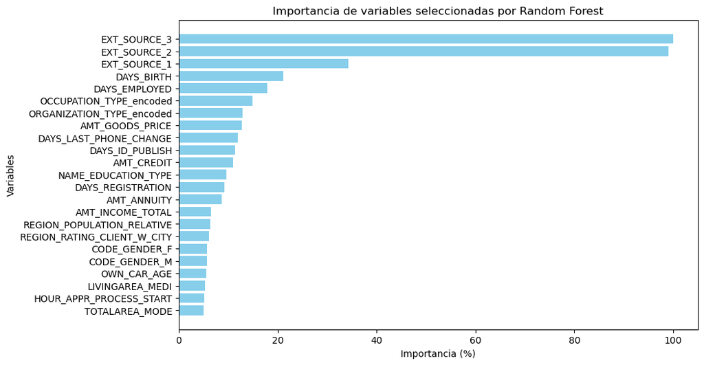

```
Variables seleccionadas (23):
                        Variable  Importancia
65                  EXT_SOURCE_3     0.160419
64                  EXT_SOURCE_2     0.158886
63                  EXT_SOURCE_1     0.055092
42                    DAYS_BIRTH     0.033823
43                 DAYS_EMPLOYED     0.028658
159      OCCUPATION_TYPE_encoded     0.023840
160    ORGANIZATION_TYPE_encoded     0.020631
11               AMT_GOODS_PRICE     0.020485
131       DAYS_LAST_PHONE_CHANGE     0.019134
45               DAYS_ID_PUBLISH     0.018294
9                     AMT_CREDIT     0.017719
28           NAME_EDUCATION_TYPE     0.015452
44             DAYS_REGISTRATION     0.014828
10                   AMT_ANNUITY     0.013932
8               AMT_INCOME_TOTAL     0.010492
41    REGION_POPULATION_RELATIVE     0.010302
55   REGION_RATING_CLIENT_W_CITY     0.009823
2                  CODE_GENDER_F     0.009210
3                  CODE_GENDER_M     0.009071
46                   OWN_CAR_AGE     0.008893
105              LIVINGAREA_MEDI     0.008474
56       HOUR_APPR_PROCESS_START     0.008322
117               TOTALAREA_MODE     0.008108
```

```python
# Importancia de las características
importancia = rf.feature_importances_

# Crear un DataFrame con las importancias
importancia_variables = pd.DataFrame({
    'Variable': X_train.columns,
    'Importancia': importancia
})

# Ordenar de mayor a menor
importancia_variables = importancia_variables.sort_values(by = 'Importancia', ascending=False)

# Filtrar las variables con importancia mayor al umbral
threshold = 0.008
variables_rf = importancia_variables[importancia_variables['Importancia'] > threshold]['Variable'].tolist()

# Porcentualizar las importancias con respecto a la máxima para graficar
importancias_filtradas = importancia_variables[importancia_variables['Importancia'] > threshold]
Porcentaje = (importancias_filtradas['Importancia'] / importancias_filtradas['Importancia'].max()) * 100.0

# Gráfico
plt.figure(figsize = (10, 6))
plt.barh(importancias_filtradas['Variable'], Porcentaje, color='skyblue')

# Configuraciones del gráfico
plt.xlabel('Importancia (%)')
plt.ylabel('Variables')
plt.title('Importancia de variables seleccionadas por Random Forest')
plt.gca().invert_yaxis()  # Invertir el eje Y para que la característica con mayor porcentaje esté arriba
plt.show()

# Imprimir las variables seleccionadas como lista
print(f"Variables seleccionadas ({len(importancias_filtradas)}):")
print(importancias_filtradas[['Variable', 'Importancia']])
```

```python
variables_rf
```

```
['EXT_SOURCE_3',
 'EXT_SOURCE_2',
 'EXT_SOURCE_1',
 'DAYS_BIRTH',
 'DAYS_EMPLOYED',
 'OCCUPATION_TYPE_encoded',
 'ORGANIZATION_TYPE_encoded',
 'AMT_GOODS_PRICE',
 'DAYS_LAST_PHONE_CHANGE',
 'DAYS_ID_PUBLISH',
 'AMT_CREDIT',
 'NAME_EDUCATION_TYPE',
 'DAYS_REGISTRATION',
 'AMT_ANNUITY',
 'AMT_INCOME_TOTAL',
 'REGION_POPULATION_RELATIVE',
 'REGION_RATING_CLIENT_W_CITY',
 'CODE_GENDER_F',
 'CODE_GENDER_M',
 'OWN_CAR_AGE',
 'LIVINGAREA_MEDI',
 'HOUR_APPR_PROCESS_START',
 'TOTALAREA_MODE']
```

#### El segundo método empleado para la selección de variables es el **Random Forest**, el cual tiene un enfoque *bagging*, en el que maneja datos no lineales al basarse en árboles de decisión que se entrenan de manera independiente. Este modelo calcula la importancia de las características y es capaz de mitigar el sobreajuste, lo que lo hace eficaz para identificar las variables más relevantes.

### *LightGBM (Light Gradient Boosting Machine)*

```python
# Limpiar nombres de columnas en X_train para evitar caracteres especiales
X_train.columns = X_train.columns.str.replace(r'\W', '_', regex=True)

# Convertir y_train a una dimensión correcta
y_train = y_train.values.ravel()  # Si es un DataFrame

lgbm = LGBMClassifier(
    n_estimators = 100,        # Número de árboles
    learning_rate = 0.05,      # Tasa de aprendizaje
    max_depth = 6,             # Profundidad máxima del árbol
    num_leaves = 31,           # Número máximo de hojas por árbol
    min_data_in_leaf = 20,     # Mínimo número de muestras por hoja
    subsample = 0.8,           # Proporción de muestras para cada árbol
    colsample_bytree = 0.8,    # Proporción de características para cada árbol
    random_state = seed        # Reproducibilidad
    )
lgbm.fit(X_train, y_train)
```

[output not shown]

```
LGBMClassifier(colsample_bytree=0.8, learning_rate=0.05, max_depth=6,
               min_data_in_leaf=20, random_state=42, subsample=0.8)
```

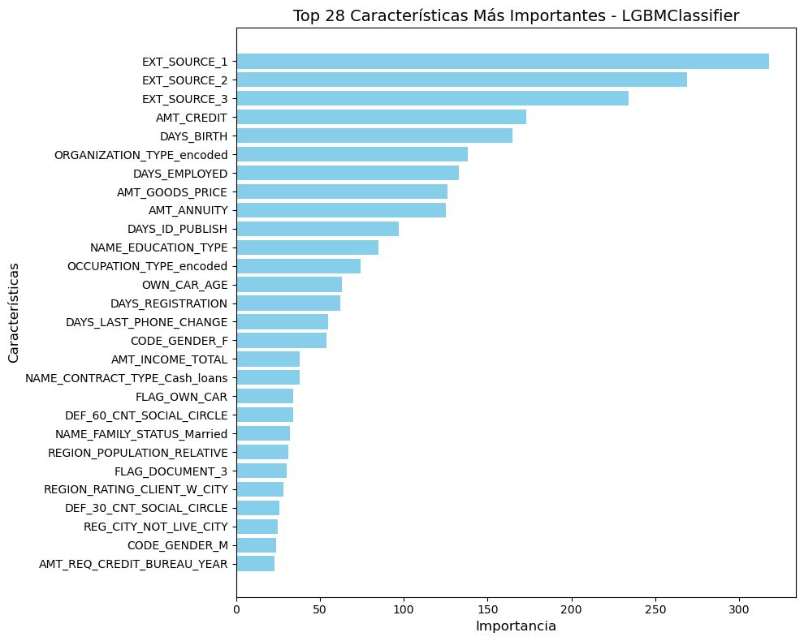

```
EXT_SOURCE_1: 318
EXT_SOURCE_2: 269
EXT_SOURCE_3: 234
AMT_CREDIT: 173
DAYS_BIRTH: 165
ORGANIZATION_TYPE_encoded: 138
DAYS_EMPLOYED: 133
AMT_GOODS_PRICE: 126
AMT_ANNUITY: 125
DAYS_ID_PUBLISH: 97
NAME_EDUCATION_TYPE: 85
OCCUPATION_TYPE_encoded: 74
OWN_CAR_AGE: 63
DAYS_REGISTRATION: 62
DAYS_LAST_PHONE_CHANGE: 55
CODE_GENDER_F: 54
AMT_INCOME_TOTAL: 38
NAME_CONTRACT_TYPE_Cash_loans: 38
FLAG_OWN_CAR: 34
DEF_60_CNT_SOCIAL_CIRCLE: 34
NAME_FAMILY_STATUS_Married: 32
REGION_POPULATION_RELATIVE: 31
FLAG_DOCUMENT_3: 30
REGION_RATING_CLIENT_W_CITY: 28
DEF_30_CNT_SOCIAL_CIRCLE: 26
REG_CITY_NOT_LIVE_CITY: 25
CODE_GENDER_M: 24
AMT_REQ_CREDIT_BUREAU_YEAR: 23
```

```python
# Importancia
importancia_lgbm = lgbm.feature_importances_

# Ordenar de manera descendente
orden = importancia_lgbm.argsort()[::-1]

# Listar las variables y sus importancias
variables_org = X_train.columns[orden]
importancia_org = importancia_lgbm[orden]

# Seleccionar las variables más importantes
variables_lgbm = variables_org[:28]
importancia_lgbm = importancia_org[:28]

# Graficar las características más importantes
plt.figure(figsize = (10,8))
plt.barh(variables_lgbm, importancia_lgbm, color = 'skyblue')
plt.xlabel('Importancia', fontsize=12)
plt.ylabel('Características', fontsize=12)
plt.title('Top 28 Características Más Importantes - LGBMClassifier', fontsize=14)
plt.gca().invert_yaxis()  # Invertir el eje Y para que la más importante esté arriba
plt.tight_layout()
plt.show()

# Mostrar las características más importantes con su valor
for variable, importancia in zip(variables_lgbm, importancia_lgbm):
    print(f'{variable}: {importancia}')
```

```python
variables_lgbm
```

```
Index(['EXT_SOURCE_1', 'EXT_SOURCE_2', 'EXT_SOURCE_3', 'AMT_CREDIT',
       'DAYS_BIRTH', 'ORGANIZATION_TYPE_encoded', 'DAYS_EMPLOYED',
       'AMT_GOODS_PRICE', 'AMT_ANNUITY', 'DAYS_ID_PUBLISH',
       'NAME_EDUCATION_TYPE', 'OCCUPATION_TYPE_encoded', 'OWN_CAR_AGE',
       'DAYS_REGISTRATION', 'DAYS_LAST_PHONE_CHANGE', 'CODE_GENDER_F',
       'AMT_INCOME_TOTAL', 'NAME_CONTRACT_TYPE_Cash_loans', 'FLAG_OWN_CAR',
       'DEF_60_CNT_SOCIAL_CIRCLE', 'NAME_FAMILY_STATUS_Married',
       'REGION_POPULATION_RELATIVE', 'FLAG_DOCUMENT_3',
       'REGION_RATING_CLIENT_W_CITY', 'DEF_30_CNT_SOCIAL_CIRCLE',
       'REG_CITY_NOT_LIVE_CITY', 'CODE_GENDER_M',
       'AMT_REQ_CREDIT_BUREAU_YEAR'],
      dtype='object')
```

#### El último método de selección de variables es **LightGBM**, un algoritmo de *boosting* que entrena árboles de manera secuencial, de modo que cada árbol corrige los errores del anterior. Este enfoque asigna importancia a las variables, descartando aquellas que tienen baja relevancia en la predicción, lo que mejora la interpretabilidad y la eficiencia del modelo.

### **Identificación e Unificación de variables relevantes**

#### Posteriormente de haber evaluado las diversas variables del conjunto de datos de entrenamiento e identificar varibles relevantes a través de distintos enfoques, en la siguiente línea de código se presentan el conjunto de variables que tienen una relevancia que no depende del método de selección, sino de su influencia sobre la variable objetivo, debido a que están presentes en todos los métodos de selección empleados.

```python
inter_variables = set(variables_lasso) & set(variables_rf) & set(variables_lgbm)
print(f"Cantidad de variables en interescción: {len(inter_variables)}")
# Función para dividir una lista en grupos de tamaño n
def chunks(lst, n):
    for i in range(0, len(lst), n):
        yield lst[i:i + n]

# Imprimir las variables en grupos de tres
print(f"Variables:")
for chunk in chunks(list(inter_variables), 3):
    print(chunk)
```

```
Cantidad de variables en interescción: 12
Variables:
['EXT_SOURCE_1', 'NAME_EDUCATION_TYPE', 'OCCUPATION_TYPE_encoded']
['EXT_SOURCE_2', 'CODE_GENDER_F', 'CODE_GENDER_M']
['ORGANIZATION_TYPE_encoded', 'DAYS_REGISTRATION', 'EXT_SOURCE_3']
['DAYS_ID_PUBLISH', 'DAYS_LAST_PHONE_CHANGE', 'REGION_RATING_CLIENT_W_CITY']
```

#### Asimismo, al identificar variables con una fuerte relación con la variable objetivo, es crucial considerar el propósito de cada método de selección de variables empleado. Por ejemplo, el método de **Lasso** se centra en la regularización, eliminando características correlacionadas, mientras que técnicas como **Random Forest** o **LightGBM** manejan bien interacciones no lineales y jerarquías entre variables, lo que las hace complementarias. A continuación se unen las listas generadas, con el fin de tomar en cuenta variables con diversos enfoques que brindan mejores rendimientos en los modelos de predicción.

```python
# Limpiar las variables de cada lista
def clean_column_names(variables):
    return [var.replace(' ', '_') for var in variables]

# Aplicar la limpieza de nombres
variables_lasso_clean = clean_column_names(variables_lasso)
variables_rf_clean = clean_column_names(variables_rf)
variables_lgbm_clean = clean_column_names(variables_lgbm)

# Realizar la unión de las listas de variables
union_variables = set(variables_lasso_clean) | set(variables_rf_clean) | set(variables_lgbm_clean)

# Imprimir la cantidad de variables en la unión
print(f'Cantidad de variables en unión: {len(union_variables)}')

# Función para dividir la lista en grupos de tamaño n
def chunks(lst, n):
    for i in range(0, len(lst), n):
        yield lst[i:i + n]

# Imprimir las variables en grupos de 5
print(f"Variables:")
for chunk in chunks(list(union_variables), 5):
    print(chunk)
```

```
Cantidad de variables en unión: 34
Variables:
['WALLSMATERIAL_MODE_Panel', 'REGION_POPULATION_RELATIVE', 'OWN_CAR_AGE', 'ORGANIZATION_TYPE_encoded', 'DEF_60_CNT_SOCIAL_CIRCLE']
['FLAG_OWN_CAR', 'EXT_SOURCE_1', 'REG_CITY_NOT_LIVE_CITY', 'EXT_SOURCE_2', 'CODE_GENDER_M']
['CODE_GENDER_F', 'REGION_RATING_CLIENT_W_CITY', 'AMT_INCOME_TOTAL', 'AMT_REQ_CREDIT_BUREAU_YEAR', 'NAME_EDUCATION_TYPE']
['LIVINGAREA_MEDI', 'NAME_CONTRACT_TYPE_Revolving_loans', 'NAME_INCOME_TYPE_Working', 'DAYS_REGISTRATION', 'AMT_ANNUITY']
['FLAG_DOCUMENT_3', 'NAME_FAMILY_STATUS_Married', 'TOTALAREA_MODE', 'EXT_SOURCE_3', 'DAYS_LAST_PHONE_CHANGE']
['DAYS_BIRTH', 'NAME_CONTRACT_TYPE_Cash_loans', 'DAYS_EMPLOYED', 'OCCUPATION_TYPE_encoded', 'DEF_30_CNT_SOCIAL_CIRCLE']
['HOUR_APPR_PROCESS_START', 'DAYS_ID_PUBLISH', 'AMT_GOODS_PRICE', 'AMT_CREDIT']
```

#### Ahora bien, generamos una lista con las variables seleccionadas para luego crear una nueva variable que contenga únicamente las columnas especificadas en la lista [lista_variables] del conjunto de datos correspondiente.

```python
lista_variables = list(union_variables)
```

#### Antes de generar la creación de la variable es necesario determinar como estara estrcuturada y así evitar errores.

```python
X_train.columns = X_train.columns.str.replace(' ', '_')
X_test.columns = X_test.columns.str.replace(' ', '_')
```

```python
X_train_m = X_train[lista_variables]
X_test_m = X_test[lista_variables]
y_train = y_train
y_test = y_test
```

```python
X_train_m
```

| SK_ID_CURR | WALLSMATERIAL_MODE_Panel | REGION_POPULATION_RELATIVE | OWN_CAR_AGE | ORGANIZATION_TYPE_encoded | DEF_60_CNT_SOCIAL_CIRCLE | FLAG_OWN_CAR | EXT_SOURCE_1 | REG_CITY_NOT_LIVE_CITY | EXT_SOURCE_2 | CODE_GENDER_M | ... | DAYS_LAST_PHONE_CHANGE | DAYS_BIRTH | NAME_CONTRACT_TYPE_Cash_loans | DAYS_EMPLOYED | OCCUPATION_TYPE_encoded | DEF_30_CNT_SOCIAL_CIRCLE | HOUR_APPR_PROCESS_START | DAYS_ID_PUBLISH | AMT_GOODS_PRICE | AMT_CREDIT |
| --- | --- | --- | --- | --- | --- | --- | --- | --- | --- | --- | --- | --- | --- | --- | --- | --- | --- | --- | --- | --- | --- |
| 310536 | 1.911670 | -0.912809 | -0.146470 | 0.280971 | -0.275731 | -0.717430 | -0.853253 | -0.290648 | -1.177100 | -0.720839 | ... | 1.164356 | 0.855291 | 0.324586 | -0.457375 | 1.115921 | -0.320807 | -0.631564 | -1.111106 | -0.970833 | -0.923256 |
| 365516 | -0.523103 | -1.285861 | 1.827430 | -0.290331 | -0.275731 | 1.393863 | 0.011861 | -0.290648 | -0.000222 | 1.387272 | ... | 0.548714 | 0.150020 | 0.324586 | -0.451322 | 1.453029 | -0.320807 | 0.287514 | 0.663110 | -1.092642 | -1.086618 |
| 242055 | 1.911670 | -0.010501 | -0.146470 | 0.600236 | -0.275731 | -0.717430 | 0.011861 | -0.290648 | -0.143502 | 1.387272 | ... | -0.618465 | -0.751224 | 0.324586 | -0.462337 | 1.115921 | -0.320807 | -2.163362 | 0.100877 | 0.040189 | 0.321581 |
| 454894 | -0.523103 | -0.661770 | -0.146470 | 0.600236 | -0.275731 | -0.717430 | 0.011861 | -0.290648 | 0.845392 | 1.387272 | ... | -1.274021 | -0.403745 | 0.324586 | -0.462372 | 1.115921 | -0.320807 | -0.631564 | 1.093404 | -0.398326 | -0.310771 |
| 448321 | -0.523103 | -1.028534 | -0.146470 | 1.788947 | -0.275731 | -0.717430 | 0.011861 | -0.290648 | -1.884246 | -0.720839 | ... | 0.323745 | 1.729030 | 0.324586 | -0.457595 | -1.568286 | -0.320807 | -2.163362 | 1.420268 | -0.849023 | -0.855766 |
| ... | ... | ... | ... | ... | ... | ... | ... | ... | ... | ... | ... | ... | ... | ... | ... | ... | ... | ... | ... | ... | ... |
| 136325 | -0.523103 | 1.079452 | -0.146470 | 0.600236 | -0.275731 | -0.717430 | 0.011861 | -0.290648 | 0.185235 | -0.720839 | ... | 0.705951 | 0.150249 | -3.080851 | -0.454887 | 0.695458 | -0.320807 | 0.593873 | -0.945353 | -0.361783 | -0.482558 |
| 240509 | 1.911670 | -0.148706 | -0.146470 | -0.664226 | -0.275731 | -0.717430 | 0.011861 | -0.290648 | 0.290166 | -0.720839 | ... | 0.711999 | -0.688879 | 0.324586 | -0.481390 | -0.414423 | -0.320807 | -1.244283 | 0.287183 | -0.849023 | -0.811517 |
| 387513 | -0.523103 | 0.311230 | -0.146470 | -1.352116 | -0.275731 | -0.717430 | 0.011861 | -0.290648 | -0.274136 | -0.720839 | ... | -0.878511 | -1.617857 | 0.324586 | 2.138211 | -0.720258 | -0.320807 | -0.325205 | -1.088564 | -0.824661 | -0.876482 |
| 303331 | -0.523103 | -0.191498 | -0.146470 | -1.352116 | -0.275731 | -0.717430 | 0.011861 | -0.290648 | -0.288762 | -0.720839 | ... | -0.443086 | -1.402402 | 0.324586 | 2.138211 | -0.720258 | -0.320807 | -0.937924 | -1.088564 | 0.734505 | 0.523091 |
| 430259 | -0.523103 | -0.145164 | -0.428456 | -1.352116 | -0.275731 | 1.393863 | 0.263766 | -0.290648 | -2.651031 | -0.720839 | ... | 0.293507 | -1.386587 | 0.324586 | 2.138211 | -0.720258 | -0.320807 | -0.018845 | -0.843250 | 0.917220 | 1.122123 |

246008 rows × 34 columns

## **Balanceo de datos**

```python
rus = RandomUnderSampler(random_state = seed)
X_resampled, y_resampled = rus.fit_resample(X_train_m, y_train) # Aplicación de submuestreo y generación de nueva data

y_resampled = pd.Series(y_resampled) # Cambio a objeto Series para un manejo más fácil

print("Distribución de clases después de Undersampling:")
print(y_resampled.value_counts())
print(y_resampled.value_counts(normalize=True))
```

```
Distribución de clases después de Undersampling:
0    19860
1    19860
Name: count, dtype: int64
0    0.5
1    0.5
Name: proportion, dtype: float64
```

#### El uso de técncias de creación de datos sintéticos es otro factor de elección de esta metodología, debido a que existen técnicas como el oversampling, donde se genera nueva información con combinaciones de datos existentes, lo cual puede llevar a que un modelo sobreajuste a patrones específicos de la clase minoritaria, siendo casos no representativos o irreales en cierto punto.

## **Guardar CSV**

```python
X_resampled.to_csv('/Users/miguelflores/Desktop/DF/X_resampled.csv')
X_test_m.to_csv('/Users/miguelflores/Desktop/DF/X_test_1.csv')

y_resampled.to_csv('/Users/miguelflores/Desktop/DF/y_resampled.csv')
y_test.to_csv('/Users/miguelflores/Desktop/DF/y_test_1.csv')
```